# Ćwiczenie 1, część 1

## Kornel Romański

### Wstęp

Część pierwsza ćwiczenia pierwszego polegała na zbadaniu działania dwuwarstwowej sieci neuronowej 256 i 14 neuronów w warstwach ukrytych) przy wymuszonych hiperparametrach w zadaniu klasyfikacji obrazu do epoki.

Poniżej przedstawiono rozkład klas w otrzymanym zbiorze testowym:

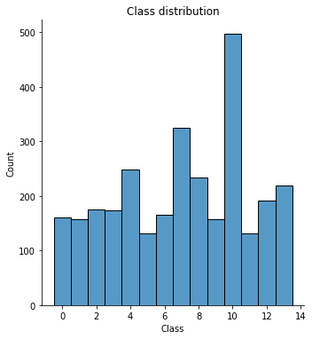

```python
# full code in jupyter notebooks
```

### Uczenie

Uczenie modelu przebiegało z wykorzystaniem poniższych hiperparametrów:

- liczba epok: 25,
- optymalizator: Adam,
- współczynnik uczenia: 0.01,
- funckcja straty: SparseCategoricalCrossentropy,
- wielkość paczki: 100

Po każdej epoce wykorzystywano również miarę F1Score do oceny modelu na zbiorze walidacyjnym.

Wartości miar w trakcie uczenia dostępne są w notebooku Assignment_1.ipynb w podglądzie aplikacji TensorBoard.

### Wyniki na zbiorze testowym

Po zakończeniu uczenia i zbadaniu działania modelu na zbiorze testowym otrzymano wynik:

```python
# full code in jupyter notebooks
```

```
Test F1: 0.20258181687144197
```

Poniżej przedstawiono macierz pomyłek oraz przykładowe błędne oraz poprawne klasyfikacje:

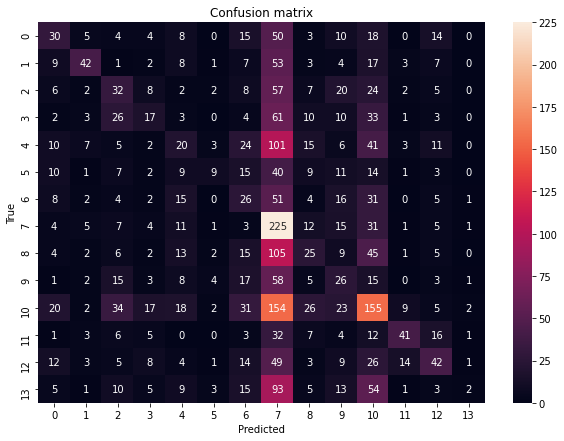

```python
# full code in jupyter notebooks
```

[figure not shown]

```python
# full code in jupyter notebooks
```

[figure not shown]

```python
# full code in jupyter notebooks
```

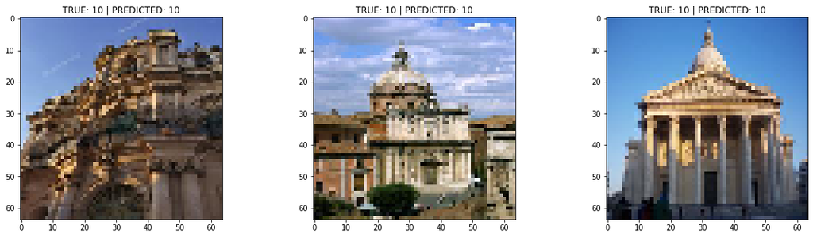

```python
# full code in jupyter notebooks
```

### Wnioski

- Proces uczenia prebiegał prawidłowo: wartość funkcji straty malała, a wartość metryki F1Score rosła.
- Model osiąga słabe wyniki. Większość zdjęć przydziela do klas 10 i 7, co może wynikać z ich nadreprezentacji w zbiorze